# Trabalhando com Coleções de Dados no R Vetores, Matrizes, Listas, Factors e Dataframes

### IMPORTANDO ARQUIVOS DE TEXTO

Para importar arquivos de texto para R, como .txt ou .csv, utilizaremos o pacote readr.

Como exemplo, utilizaremos uma base de filmes do IMDB, gravada em diversos formatos. Os arquivos podem ser encontrados neste [link](https://github.com/curso-r/site-v2/tree/master/content/material/importacao/data).

```r
library(readr)

imdb_csv <- read_csv(file = "https://raw.githubusercontent.com/curso-r/site-v2/master/content/material/importacao/data/imdb.csv")
imdb_txt <- read_delim(file = "https://raw.githubusercontent.com/curso-r/site-v2/master/content/material/importacao/data/imdb.txt", delim = " ")
```

```r
dim(imdb_csv)
```

1. 3807

2. 15

```r
imdb_txt
```

A spec_tbl_df: 3807 × 15

| titulo <chr> | ano <dbl> | diretor <chr> | duracao <dbl> | cor <chr> | generos <chr> | pais <chr> | classificacao <chr> | orcamento <dbl> | receita <dbl> | nota_imdb <dbl> | likes_facebook <dbl> | ator_1 <chr> | ator_2 <chr> | ator_3 <chr> |
| --- | --- | --- | --- | --- | --- | --- | --- | --- | --- | --- | --- | --- | --- | --- |
| Avatar | 2009 | James Cameron | 178 | Color | Action\|Adventure\|Fantasy\|Sci-Fi | USA | A partir de 13 anos | 237000000 | 760505847 | 7.9 | 33000 | CCH Pounder | Joel David Moore | Wes Studi |
| Pirates of the Caribbean: At World's End | 2007 | Gore Verbinski | 169 | Color | Action\|Adventure\|Fantasy | USA | A partir de 13 anos | 300000000 | 309404152 | 7.1 | 0 | Johnny Depp | Orlando Bloom | Jack Davenport |
| The Dark Knight Rises | 2012 | Christopher Nolan | 164 | Color | Action\|Thriller | USA | A partir de 13 anos | 250000000 | 448130642 | 8.5 | 164000 | Tom Hardy | Christian Bale | Joseph Gordon-Levitt |
| John Carter | 2012 | Andrew Stanton | 132 | Color | Action\|Adventure\|Sci-Fi | USA | A partir de 13 anos | 263700000 | 73058679 | 6.6 | 24000 | Daryl Sabara | Samantha Morton | Polly Walker |
| Spider-Man 3 | 2007 | Sam Raimi | 156 | Color | Action\|Adventure\|Romance | USA | A partir de 13 anos | 258000000 | 336530303 | 6.2 | 0 | J.K. Simmons | James Franco | Kirsten Dunst |
| Tangled | 2010 | Nathan Greno | 100 | Color | Adventure\|Animation\|Comedy\|Family\|Fantasy\|Musical\|Romance | USA | Livre | 260000000 | 200807262 | 7.8 | 29000 | Brad Garrett | Donna Murphy | M.C. Gainey |
| Avengers: Age of Ultron | 2015 | Joss Whedon | 141 | Color | Action\|Adventure\|Sci-Fi | USA | A partir de 13 anos | 250000000 | 458991599 | 7.5 | 118000 | Chris Hemsworth | Robert Downey Jr. | Scarlett Johansson |
| Batman v Superman: Dawn of Justice | 2016 | Zack Snyder | 183 | Color | Action\|Adventure\|Sci-Fi | USA | A partir de 13 anos | 250000000 | 330249062 | 6.9 | 197000 | Henry Cavill | Lauren Cohan | Alan D. Purwin |
| Superman Returns | 2006 | Bryan Singer | 169 | Color | Action\|Adventure\|Sci-Fi | USA | A partir de 13 anos | 209000000 | 200069408 | 6.1 | 0 | Kevin Spacey | Marlon Brando | Frank Langella |
| Pirates of the Caribbean: Dead Man's Chest | 2006 | Gore Verbinski | 151 | Color | Action\|Adventure\|Fantasy | USA | A partir de 13 anos | 225000000 | 423032628 | 7.3 | 5000 | Johnny Depp | Orlando Bloom | Jack Davenport |
| The Lone Ranger | 2013 | Gore Verbinski | 150 | Color | Action\|Adventure\|Western | USA | A partir de 13 anos | 215000000 | 89289910 | 6.5 | 48000 | Johnny Depp | Ruth Wilson | Tom Wilkinson |
| Man of Steel | 2013 | Zack Snyder | 143 | Color | Action\|Adventure\|Fantasy\|Sci-Fi | USA | A partir de 13 anos | 225000000 | 291021565 | 7.2 | 118000 | Henry Cavill | Christopher Meloni | Harry Lennix |
| The Chronicles of Narnia: Prince Caspian | 2008 | Andrew Adamson | 150 | Color | Action\|Adventure\|Family\|Fantasy | USA | Livre | 225000000 | 141614023 | 6.6 | 0 | Peter Dinklage | Pierfrancesco Favino | Damián Alcázar |
| The Avengers | 2012 | Joss Whedon | 173 | Color | Action\|Adventure\|Sci-Fi | USA | A partir de 13 anos | 220000000 | 623279547 | 8.1 | 123000 | Chris Hemsworth | Robert Downey Jr. | Scarlett Johansson |
| Pirates of the Caribbean: On Stranger Tides | 2011 | Rob Marshall | 136 | Color | Action\|Adventure\|Fantasy | USA | A partir de 13 anos | 250000000 | 241063875 | 6.7 | 58000 | Johnny Depp | Sam Claflin | Stephen Graham |
| Men in Black 3 | 2012 | Barry Sonnenfeld | 106 | Color | Action\|Adventure\|Comedy\|Family\|Fantasy\|Sci-Fi | USA | A partir de 13 anos | 225000000 | 179020854 | 6.8 | 40000 | Will Smith | Michael Stuhlbarg | Nicole Scherzinger |
| The Amazing Spider-Man | 2012 | Marc Webb | 153 | Color | Action\|Adventure\|Fantasy | USA | A partir de 13 anos | 230000000 | 262030663 | 7.0 | 56000 | Emma Stone | Andrew Garfield | Chris Zylka |
| Robin Hood | 2010 | Ridley Scott | 156 | Color | Action\|Adventure\|Drama\|History | USA | A partir de 13 anos | 200000000 | 105219735 | 6.7 | 17000 | Mark Addy | William Hurt | Scott Grimes |
| The Hobbit: The Desolation of Smaug | 2013 | Peter Jackson | 186 | Color | Adventure\|Fantasy | USA | A partir de 13 anos | 225000000 | 258355354 | 7.9 | 83000 | Aidan Turner | Adam Brown | James Nesbitt |
| The Golden Compass | 2007 | Chris Weitz | 113 | Color | Adventure\|Family\|Fantasy | USA | A partir de 13 anos | 180000000 | 70083519 | 6.1 | 0 | Christopher Lee | Eva Green | Kristin Scott Thomas |
| Titanic | 1997 | James Cameron | 194 | Color | Drama\|Romance | USA | A partir de 13 anos | 200000000 | 658672302 | 7.7 | 26000 | Leonardo DiCaprio | Kate Winslet | Gloria Stuart |
| Captain America: Civil War | 2016 | Anthony Russo | 147 | Color | Action\|Adventure\|Sci-Fi | USA | A partir de 13 anos | 250000000 | 407197282 | 8.2 | 72000 | Robert Downey Jr. | Scarlett Johansson | Chris Evans |
| Battleship | 2012 | Peter Berg | 131 | Color | Action\|Adventure\|Sci-Fi\|Thriller | USA | A partir de 13 anos | 209000000 | 65173160 | 5.9 | 44000 | Liam Neeson | Alexander Skarsgård | Tadanobu Asano |
| Jurassic World | 2015 | Colin Trevorrow | 124 | Color | Action\|Adventure\|Sci-Fi\|Thriller | USA | A partir de 13 anos | 150000000 | 652177271 | 7.0 | 150000 | Bryce Dallas Howard | Judy Greer | Omar Sy |
| Spider-Man 2 | 2004 | Sam Raimi | 135 | Color | Action\|Adventure\|Fantasy\|Romance | USA | A partir de 13 anos | 200000000 | 373377893 | 7.3 | 0 | J.K. Simmons | James Franco | Kirsten Dunst |
| Iron Man 3 | 2013 | Shane Black | 195 | Color | Action\|Adventure\|Sci-Fi | USA | A partir de 13 anos | 200000000 | 408992272 | 7.2 | 95000 | Robert Downey Jr. | Jon Favreau | Don Cheadle |
| Alice in Wonderland | 2010 | Tim Burton | 108 | Color | Adventure\|Family\|Fantasy | USA | Livre | 200000000 | 334185206 | 6.5 | 24000 | Johnny Depp | Alan Rickman | Anne Hathaway |
| Monsters University | 2013 | Dan Scanlon | 104 | Color | Adventure\|Animation\|Comedy\|Family\|Fantasy | USA | Outros | 200000000 | 268488329 | 7.3 | 44000 | Steve Buscemi | Tyler Labine | Sean Hayes |
| Transformers: Revenge of the Fallen | 2009 | Michael Bay | 150 | Color | Action\|Adventure\|Sci-Fi | USA | A partir de 13 anos | 200000000 | 402076689 | 6.0 | 0 | Glenn Morshower | Kevin Dunn | Ramon Rodriguez |
| Transformers: Age of Extinction | 2014 | Michael Bay | 165 | Color | Action\|Adventure\|Sci-Fi | USA | A partir de 13 anos | 210000000 | 245428137 | 5.7 | 56000 | Bingbing Li | Sophia Myles | Kelsey Grammer |
| ... | ... | ... | ... | ... | ... | ... | ... | ... | ... | ... | ... | ... | ... | ... |
| The Exploding Girl | 2009 | Bradley Rust Gray | 79 | Color | Drama | USA | Outros | NA | 24705 | 6.3 | 377 | Zoe Kazan | Mark Rendall | Jordan Scovel |
| The Legend of God's Gun | 2007 | Mike Bruce | 78 | Color | Western | USA | A partir de 18 anos | 30000 | 243768 | 4.1 | 13 | Joseph Campanella | Kirpatrick Thomas | Christian Anderson |
| Mutual Appreciation | 2005 | Andrew Bujalski | 109 | Black and White | Comedy | USA | A partir de 18 anos | NA | NA | 6.9 | 91 | Andrew Bujalski | Kate Dollenmayer | Justin Rice |
| Her Cry: La Llorona Investigation | 2013 | Damir Catic | 89 | Color | Horror | USA | Outros | 60000 | NA | 5.4 | 48 | Nichole Ceballos | Ron Gelner | Parker Riggs |
| Clerks | 1994 | Kevin Smith | 102 | Black and White | Comedy | USA | A partir de 18 anos | 230000 | 3151130 | 7.8 | 0 | Jason Mewes | Brian O'Halloran | Jeff Anderson |
| Pink Narcissus | 1971 | James Bidgood | 65 | Color | Drama\|Fantasy | USA | Outros | 27000 | 8231 | 6.7 | 85 | Don Brooks | Bobby Kendall | NA |
| Funny Ha Ha | 2002 | Andrew Bujalski | 85 | Color | Comedy\|Drama | USA | Outros | NA | NA | 6.4 | 108 | Andrew Bujalski | Kate Dollenmayer | Justin Rice |
| Sabotage | 2014 | David Ayer | 109 | Color | Action\|Crime\|Drama\|Thriller | USA | A partir de 18 anos | 35000000 | 10499968 | 5.7 | 10000 | Mireille Enos | Martin Donovan | Maurice Compte |
| Manito | 2002 | Eric Eason | 79 | Color | Drama\|Family | USA | Outros | 24000 | NA | 7.0 | 61 | Franky G | Panchito Gómez | Casper Martinez |
| Slacker | 1991 | Richard Linklater | 100 | Black and White | Comedy\|Drama | USA | A partir de 18 anos | 23000 | 1227508 | 7.1 | 2000 | Tommy Pallotta | Richard Linklater | Jean Caffeine |
| Dutch Kills | 2015 | Joseph Mazzella | 90 | Color | Crime\|Drama\|Thriller | USA | Outros | 25000 | NA | 4.8 | 33 | Tjasa Ferme | Mikaal Bates | Damon Owlia |
| Dry Spell | 2013 | Travis Legge | 90 | Color | Comedy\|Romance | USA | Outros | 22000 | NA | 3.3 | 200 | Kristen Seavey | Suzi Lorraine | Travis Legge |
| Flywheel | 2003 | Alex Kendrick | 120 | Color | Drama | USA | Outros | 20000 | NA | 6.9 | 725 | Shannen Fields | Lisa Arnold | Janet Lee Dapper |
| Exeter | 2015 | Marcus Nispel | 91 | Color | Horror\|Mystery\|Thriller | USA | A partir de 18 anos | NA | NA | 4.6 | 0 | Ashley Tramonte | Brittany Curran | Lindsay MacDonald |
| The Ridges | 2011 | Brandon Landers | 143 | NA | Drama\|Horror\|Thriller | USA | Outros | 17350 | NA | 3.0 | 33 | Robbie Barnes | Alana Kaniewski | Brandon Landers |
| The Puffy Chair | 2005 | Jay Duplass | 85 | Color | Comedy\|Drama\|Romance | USA | A partir de 18 anos | 15000 | 192467 | 6.6 | 297 | Mark Duplass | Katie Aselton | Bari Hyman |
| Breaking Upwards | 2009 | Daryl Wein | 88 | Color | Romance | USA | Outros | 15000 | 76382 | 6.2 | 324 | Zoe Lister-Jones | Heather Burns | Ebon Moss-Bachrach |
| All Superheroes Must Die | 2011 | Jason Trost | 78 | Color | Sci-Fi\|Thriller | USA | Outros | 20000 | NA | 4.0 | 835 | Sean Whalen | Jason Trost | Nick Principe |
| Pink Flamingos | 1972 | John Waters | 108 | Color | Comedy\|Crime\|Horror | USA | A partir de 18 anos | 10000 | 180483 | 6.1 | 0 | Divine | Mink Stole | Edith Massey |
| On the Downlow | 2004 | Tadeo Garcia | 84 | Color | Drama | USA | Outros | NA | NA | 6.1 | 22 | Tatiana Suarez-Pico | Michael Cortez | Eric Ambriz |
| Sanctuary; Quite a Conundrum | 2012 | Thomas L. Phillips | 82 | Color | Comedy\|Horror\|Thriller | USA | Outros | 200000 | NA | 5.4 | 424 | Julianna Pitt | Joe Coffey | John Lucas |
| Bang | 1995 | Ash Baron-Cohen | 98 | Color | Crime\|Drama | USA | Outros | NA | NA | 6.4 | 20 | Peter Greene | Stanley B. Herman | James Noble |
| Primer | 2004 | Shane Carruth | 77 | Color | Drama\|Sci-Fi\|Thriller | USA | A partir de 13 anos | 7000 | 424760 | 7.0 | 19000 | Shane Carruth | David Sullivan | Casey Gooden |
| El Mariachi | 1992 | Robert Rodriguez | 81 | Color | Action\|Crime\|Drama\|Romance\|Thriller | USA | A partir de 18 anos | 7000 | 2040920 | 6.9 | 0 | Carlos Gallardo | Peter Marquardt | Consuelo Gómez |
| The Mongol King | 2005 | Anthony Vallone | 84 | Color | Crime\|Drama | USA | A partir de 13 anos | 3250 | NA | 7.8 | 4 | Richard Jewell | John Considine | Sara Stepnicka |
| Newlyweds | 2011 | Edward Burns | 95 | Color | Comedy\|Drama | USA | Outros | 9000 | 4584 | 6.4 | 413 | Kerry Bishé | Caitlin FitzGerald | Daniella Pineda |
| The Following | NA | NA | 43 | Color | Crime\|Drama\|Mystery\|Thriller | USA | Outros | NA | NA | 7.5 | 32000 | Natalie Zea | Valorie Curry | Sam Underwood |
| A Plague So Pleasant | 2013 | Benjamin Roberds | 76 | Color | Drama\|Horror\|Thriller | USA | Outros | 1400 | NA | 6.3 | 16 | Eva Boehnke | Maxwell Moody | David Chandler |
| Shanghai Calling | 2012 | Daniel Hsia | 100 | Color | Comedy\|Drama\|Romance | USA | A partir de 13 anos | NA | 10443 | 6.3 | 660 | Alan Ruck | Daniel Henney | Eliza Coupe |
| My Date with Drew | 2004 | Jon Gunn | 90 | Color | Documentary | USA | Livre | 1100 | 85222 | 6.6 | 456 | John August | Brian Herzlinger | Jon Gunn |

Repare que o argumento `file=` representa o caminho até o arquivo. Se o arquivo a ser lido não estiver no diretório de trabalho da sua sessão, você precisa especificar o caminho até o arquivo. O argumento `delim=` indica qual caracter separa cada coluna no arquivo de texto.

Para a maioria das funções `read_`, existe uma respectiva função `write_`.

Essas funções servem para salvar bases em um formato específico de arquivo.

Além do nome do arquivo a ser criado, você também precisa passar o objeto que será gravado. Repare nos exemplos abaixo que você precisa especificar a extensão do arquivo corretamente.

```r
write_csv(x = mtcars, path = "data\\mtcars.csv")
write_delim(x = mtcars, delim = " ", path = "data\\mtcars.txt")
```

Também é possível salvar objetos, como data.frames em um tipo especial de arquivos, o .rds.

A vantagem dessa extensão é guardar a estrutura dos dados salvos, como a classe das colunas de um data.frame.

Além disso, é uma boa alternativa para lidar com grandes bancos de dados, já que arquivos .rds serão bem mais compactos do que arquivos Excel.

```r
imdb_rds <- read_rds(path = "imdb.rds")
write_rds(mtcars, path = "mtcars.rds")
```

### IMPORTANDO ARQUIVOS DO EXCEL

O pacote `readxl` contém funções para ler dados de arquivos do Excel, como `.xls` e `xlsx`.

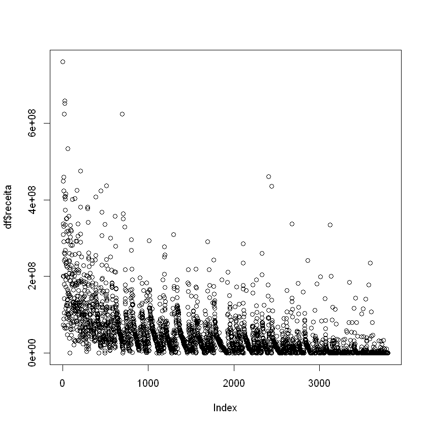

```r
df <- readxl::read_xls(path = "imdb.xls")
plot(df$receita)
```

```r
readxl::read_xlsx(path = "imdb.xlsx")
```

A tibble: 3807 × 15

| titulo <chr> | ano <dbl> | diretor <chr> | duracao <dbl> | cor <chr> | generos <chr> | pais <chr> | classificacao <chr> | orcamento <dbl> | receita <dbl> | nota_imdb <dbl> | likes_facebook <dbl> | ator_1 <chr> | ator_2 <chr> | ator_3 <chr> |
| --- | --- | --- | --- | --- | --- | --- | --- | --- | --- | --- | --- | --- | --- | --- |
| Avatar | 2009 | James Cameron | 178 | Color | Action\|Adventure\|Fantasy\|Sci-Fi | USA | A partir de 13 anos | 237000000 | 760505847 | 7.9 | 33000 | CCH Pounder | Joel David Moore | Wes Studi |
| Pirates of the Caribbean: At World's End | 2007 | Gore Verbinski | 169 | Color | Action\|Adventure\|Fantasy | USA | A partir de 13 anos | 300000000 | 309404152 | 7.1 | 0 | Johnny Depp | Orlando Bloom | Jack Davenport |
| The Dark Knight Rises | 2012 | Christopher Nolan | 164 | Color | Action\|Thriller | USA | A partir de 13 anos | 250000000 | 448130642 | 8.5 | 164000 | Tom Hardy | Christian Bale | Joseph Gordon-Levitt |
| John Carter | 2012 | Andrew Stanton | 132 | Color | Action\|Adventure\|Sci-Fi | USA | A partir de 13 anos | 263700000 | 73058679 | 6.6 | 24000 | Daryl Sabara | Samantha Morton | Polly Walker |
| Spider-Man 3 | 2007 | Sam Raimi | 156 | Color | Action\|Adventure\|Romance | USA | A partir de 13 anos | 258000000 | 336530303 | 6.2 | 0 | J.K. Simmons | James Franco | Kirsten Dunst |
| Tangled | 2010 | Nathan Greno | 100 | Color | Adventure\|Animation\|Comedy\|Family\|Fantasy\|Musical\|Romance | USA | Livre | 260000000 | 200807262 | 7.8 | 29000 | Brad Garrett | Donna Murphy | M.C. Gainey |
| Avengers: Age of Ultron | 2015 | Joss Whedon | 141 | Color | Action\|Adventure\|Sci-Fi | USA | A partir de 13 anos | 250000000 | 458991599 | 7.5 | 118000 | Chris Hemsworth | Robert Downey Jr. | Scarlett Johansson |
| Batman v Superman: Dawn of Justice | 2016 | Zack Snyder | 183 | Color | Action\|Adventure\|Sci-Fi | USA | A partir de 13 anos | 250000000 | 330249062 | 6.9 | 197000 | Henry Cavill | Lauren Cohan | Alan D. Purwin |
| Superman Returns | 2006 | Bryan Singer | 169 | Color | Action\|Adventure\|Sci-Fi | USA | A partir de 13 anos | 209000000 | 200069408 | 6.1 | 0 | Kevin Spacey | Marlon Brando | Frank Langella |
| Pirates of the Caribbean: Dead Man's Chest | 2006 | Gore Verbinski | 151 | Color | Action\|Adventure\|Fantasy | USA | A partir de 13 anos | 225000000 | 423032628 | 7.3 | 5000 | Johnny Depp | Orlando Bloom | Jack Davenport |
| The Lone Ranger | 2013 | Gore Verbinski | 150 | Color | Action\|Adventure\|Western | USA | A partir de 13 anos | 215000000 | 89289910 | 6.5 | 48000 | Johnny Depp | Ruth Wilson | Tom Wilkinson |
| Man of Steel | 2013 | Zack Snyder | 143 | Color | Action\|Adventure\|Fantasy\|Sci-Fi | USA | A partir de 13 anos | 225000000 | 291021565 | 7.2 | 118000 | Henry Cavill | Christopher Meloni | Harry Lennix |
| The Chronicles of Narnia: Prince Caspian | 2008 | Andrew Adamson | 150 | Color | Action\|Adventure\|Family\|Fantasy | USA | Livre | 225000000 | 141614023 | 6.6 | 0 | Peter Dinklage | Pierfrancesco Favino | Damián Alcázar |
| The Avengers | 2012 | Joss Whedon | 173 | Color | Action\|Adventure\|Sci-Fi | USA | A partir de 13 anos | 220000000 | 623279547 | 8.1 | 123000 | Chris Hemsworth | Robert Downey Jr. | Scarlett Johansson |
| Pirates of the Caribbean: On Stranger Tides | 2011 | Rob Marshall | 136 | Color | Action\|Adventure\|Fantasy | USA | A partir de 13 anos | 250000000 | 241063875 | 6.7 | 58000 | Johnny Depp | Sam Claflin | Stephen Graham |
| Men in Black 3 | 2012 | Barry Sonnenfeld | 106 | Color | Action\|Adventure\|Comedy\|Family\|Fantasy\|Sci-Fi | USA | A partir de 13 anos | 225000000 | 179020854 | 6.8 | 40000 | Will Smith | Michael Stuhlbarg | Nicole Scherzinger |
| The Amazing Spider-Man | 2012 | Marc Webb | 153 | Color | Action\|Adventure\|Fantasy | USA | A partir de 13 anos | 230000000 | 262030663 | 7.0 | 56000 | Emma Stone | Andrew Garfield | Chris Zylka |
| Robin Hood | 2010 | Ridley Scott | 156 | Color | Action\|Adventure\|Drama\|History | USA | A partir de 13 anos | 200000000 | 105219735 | 6.7 | 17000 | Mark Addy | William Hurt | Scott Grimes |
| The Hobbit: The Desolation of Smaug | 2013 | Peter Jackson | 186 | Color | Adventure\|Fantasy | USA | A partir de 13 anos | 225000000 | 258355354 | 7.9 | 83000 | Aidan Turner | Adam Brown | James Nesbitt |
| The Golden Compass | 2007 | Chris Weitz | 113 | Color | Adventure\|Family\|Fantasy | USA | A partir de 13 anos | 180000000 | 70083519 | 6.1 | 0 | Christopher Lee | Eva Green | Kristin Scott Thomas |
| Titanic | 1997 | James Cameron | 194 | Color | Drama\|Romance | USA | A partir de 13 anos | 200000000 | 658672302 | 7.7 | 26000 | Leonardo DiCaprio | Kate Winslet | Gloria Stuart |
| Captain America: Civil War | 2016 | Anthony Russo | 147 | Color | Action\|Adventure\|Sci-Fi | USA | A partir de 13 anos | 250000000 | 407197282 | 8.2 | 72000 | Robert Downey Jr. | Scarlett Johansson | Chris Evans |
| Battleship | 2012 | Peter Berg | 131 | Color | Action\|Adventure\|Sci-Fi\|Thriller | USA | A partir de 13 anos | 209000000 | 65173160 | 5.9 | 44000 | Liam Neeson | Alexander Skarsgård | Tadanobu Asano |
| Jurassic World | 2015 | Colin Trevorrow | 124 | Color | Action\|Adventure\|Sci-Fi\|Thriller | USA | A partir de 13 anos | 150000000 | 652177271 | 7.0 | 150000 | Bryce Dallas Howard | Judy Greer | Omar Sy |
| Spider-Man 2 | 2004 | Sam Raimi | 135 | Color | Action\|Adventure\|Fantasy\|Romance | USA | A partir de 13 anos | 200000000 | 373377893 | 7.3 | 0 | J.K. Simmons | James Franco | Kirsten Dunst |
| Iron Man 3 | 2013 | Shane Black | 195 | Color | Action\|Adventure\|Sci-Fi | USA | A partir de 13 anos | 200000000 | 408992272 | 7.2 | 95000 | Robert Downey Jr. | Jon Favreau | Don Cheadle |
| Alice in Wonderland | 2010 | Tim Burton | 108 | Color | Adventure\|Family\|Fantasy | USA | Livre | 200000000 | 334185206 | 6.5 | 24000 | Johnny Depp | Alan Rickman | Anne Hathaway |
| Monsters University | 2013 | Dan Scanlon | 104 | Color | Adventure\|Animation\|Comedy\|Family\|Fantasy | USA | Outros | 200000000 | 268488329 | 7.3 | 44000 | Steve Buscemi | Tyler Labine | Sean Hayes |
| Transformers: Revenge of the Fallen | 2009 | Michael Bay | 150 | Color | Action\|Adventure\|Sci-Fi | USA | A partir de 13 anos | 200000000 | 402076689 | 6.0 | 0 | Glenn Morshower | Kevin Dunn | Ramon Rodriguez |
| Transformers: Age of Extinction | 2014 | Michael Bay | 165 | Color | Action\|Adventure\|Sci-Fi | USA | A partir de 13 anos | 210000000 | 245428137 | 5.7 | 56000 | Bingbing Li | Sophia Myles | Kelsey Grammer |
| ... | ... | ... | ... | ... | ... | ... | ... | ... | ... | ... | ... | ... | ... | ... |
| The Exploding Girl | 2009 | Bradley Rust Gray | 79 | Color | Drama | USA | Outros | NA | 24705 | 6.3 | 377 | Zoe Kazan | Mark Rendall | Jordan Scovel |
| The Legend of God's Gun | 2007 | Mike Bruce | 78 | Color | Western | USA | A partir de 18 anos | 30000 | 243768 | 4.1 | 13 | Joseph Campanella | Kirpatrick Thomas | Christian Anderson |
| Mutual Appreciation | 2005 | Andrew Bujalski | 109 | Black and White | Comedy | USA | A partir de 18 anos | NA | NA | 6.9 | 91 | Andrew Bujalski | Kate Dollenmayer | Justin Rice |
| Her Cry: La Llorona Investigation | 2013 | Damir Catic | 89 | Color | Horror | USA | Outros | 60000 | NA | 5.4 | 48 | Nichole Ceballos | Ron Gelner | Parker Riggs |
| Clerks | 1994 | Kevin Smith | 102 | Black and White | Comedy | USA | A partir de 18 anos | 230000 | 3151130 | 7.8 | 0 | Jason Mewes | Brian O'Halloran | Jeff Anderson |
| Pink Narcissus | 1971 | James Bidgood | 65 | Color | Drama\|Fantasy | USA | Outros | 27000 | 8231 | 6.7 | 85 | Don Brooks | Bobby Kendall | NA |
| Funny Ha Ha | 2002 | Andrew Bujalski | 85 | Color | Comedy\|Drama | USA | Outros | NA | NA | 6.4 | 108 | Andrew Bujalski | Kate Dollenmayer | Justin Rice |
| Sabotage | 2014 | David Ayer | 109 | Color | Action\|Crime\|Drama\|Thriller | USA | A partir de 18 anos | 35000000 | 10499968 | 5.7 | 10000 | Mireille Enos | Martin Donovan | Maurice Compte |
| Manito | 2002 | Eric Eason | 79 | Color | Drama\|Family | USA | Outros | 24000 | NA | 7.0 | 61 | Franky G | Panchito Gómez | Casper Martinez |
| Slacker | 1991 | Richard Linklater | 100 | Black and White | Comedy\|Drama | USA | A partir de 18 anos | 23000 | 1227508 | 7.1 | 2000 | Tommy Pallotta | Richard Linklater | Jean Caffeine |
| Dutch Kills | 2015 | Joseph Mazzella | 90 | Color | Crime\|Drama\|Thriller | USA | Outros | 25000 | NA | 4.8 | 33 | Tjasa Ferme | Mikaal Bates | Damon Owlia |
| Dry Spell | 2013 | Travis Legge | 90 | Color | Comedy\|Romance | USA | Outros | 22000 | NA | 3.3 | 200 | Kristen Seavey | Suzi Lorraine | Travis Legge |
| Flywheel | 2003 | Alex Kendrick | 120 | Color | Drama | USA | Outros | 20000 | NA | 6.9 | 725 | Shannen Fields | Lisa Arnold | Janet Lee Dapper |
| Exeter | 2015 | Marcus Nispel | 91 | Color | Horror\|Mystery\|Thriller | USA | A partir de 18 anos | NA | NA | 4.6 | 0 | Ashley Tramonte | Brittany Curran | Lindsay MacDonald |
| The Ridges | 2011 | Brandon Landers | 143 | NA | Drama\|Horror\|Thriller | USA | Outros | 17350 | NA | 3.0 | 33 | Robbie Barnes | Alana Kaniewski | Brandon Landers |
| The Puffy Chair | 2005 | Jay Duplass | 85 | Color | Comedy\|Drama\|Romance | USA | A partir de 18 anos | 15000 | 192467 | 6.6 | 297 | Mark Duplass | Katie Aselton | Bari Hyman |
| Breaking Upwards | 2009 | Daryl Wein | 88 | Color | Romance | USA | Outros | 15000 | 76382 | 6.2 | 324 | Zoe Lister-Jones | Heather Burns | Ebon Moss-Bachrach |
| All Superheroes Must Die | 2011 | Jason Trost | 78 | Color | Sci-Fi\|Thriller | USA | Outros | 20000 | NA | 4.0 | 835 | Sean Whalen | Jason Trost | Nick Principe |
| Pink Flamingos | 1972 | John Waters | 108 | Color | Comedy\|Crime\|Horror | USA | A partir de 18 anos | 10000 | 180483 | 6.1 | 0 | Divine | Mink Stole | Edith Massey |
| On the Downlow | 2004 | Tadeo Garcia | 84 | Color | Drama | USA | Outros | NA | NA | 6.1 | 22 | Tatiana Suarez-Pico | Michael Cortez | Eric Ambriz |
| Sanctuary; Quite a Conundrum | 2012 | Thomas L. Phillips | 82 | Color | Comedy\|Horror\|Thriller | USA | Outros | 200000 | NA | 5.4 | 424 | Julianna Pitt | Joe Coffey | John Lucas |
| Bang | 1995 | Ash Baron-Cohen | 98 | Color | Crime\|Drama | USA | Outros | NA | NA | 6.4 | 20 | Peter Greene | Stanley B. Herman | James Noble |
| Primer | 2004 | Shane Carruth | 77 | Color | Drama\|Sci-Fi\|Thriller | USA | A partir de 13 anos | 7000 | 424760 | 7.0 | 19000 | Shane Carruth | David Sullivan | Casey Gooden |
| El Mariachi | 1992 | Robert Rodriguez | 81 | Color | Action\|Crime\|Drama\|Romance\|Thriller | USA | A partir de 18 anos | 7000 | 2040920 | 6.9 | 0 | Carlos Gallardo | Peter Marquardt | Consuelo Gómez |
| The Mongol King | 2005 | Anthony Vallone | 84 | Color | Crime\|Drama | USA | A partir de 13 anos | 3250 | NA | 7.8 | 4 | Richard Jewell | John Considine | Sara Stepnicka |
| Newlyweds | 2011 | Edward Burns | 95 | Color | Comedy\|Drama | USA | Outros | 9000 | 4584 | 6.4 | 413 | Kerry Bishé | Caitlin FitzGerald | Daniella Pineda |
| The Following | NA | NA | 43 | Color | Crime\|Drama\|Mystery\|Thriller | USA | Outros | NA | NA | 7.5 | 32000 | Natalie Zea | Valorie Curry | Sam Underwood |
| A Plague So Pleasant | 2013 | Benjamin Roberds | 76 | Color | Drama\|Horror\|Thriller | USA | Outros | 1400 | NA | 6.3 | 16 | Eva Boehnke | Maxwell Moody | David Chandler |
| Shanghai Calling | 2012 | Daniel Hsia | 100 | Color | Comedy\|Drama\|Romance | USA | A partir de 13 anos | NA | 10443 | 6.3 | 660 | Alan Ruck | Daniel Henney | Eliza Coupe |
| My Date with Drew | 2004 | Jon Gunn | 90 | Color | Documentary | USA | Livre | 1100 | 85222 | 6.6 | 456 | John August | Brian Herzlinger | Jon Gunn |

A funçao `read_excel()` auto detecta a extensão do arquivo.

```r
readxl::read_excel(path = "imdb.xls")
```

A tibble: 3807 × 15

| titulo <chr> | ano <dbl> | diretor <chr> | duracao <dbl> | cor <chr> | generos <chr> | pais <chr> | classificacao <chr> | orcamento <dbl> | receita <dbl> | nota_imdb <dbl> | likes_facebook <dbl> | ator_1 <chr> | ator_2 <chr> | ator_3 <chr> |
| --- | --- | --- | --- | --- | --- | --- | --- | --- | --- | --- | --- | --- | --- | --- |
| Avatar | 2009 | James Cameron | 178 | Color | Action\|Adventure\|Fantasy\|Sci-Fi | USA | A partir de 13 anos | 237000000 | 760505847 | 7.9 | 33000 | CCH Pounder | Joel David Moore | Wes Studi |
| Pirates of the Caribbean: At World's End | 2007 | Gore Verbinski | 169 | Color | Action\|Adventure\|Fantasy | USA | A partir de 13 anos | 300000000 | 309404152 | 7.1 | 0 | Johnny Depp | Orlando Bloom | Jack Davenport |
| The Dark Knight Rises | 2012 | Christopher Nolan | 164 | Color | Action\|Thriller | USA | A partir de 13 anos | 250000000 | 448130642 | 8.5 | 164000 | Tom Hardy | Christian Bale | Joseph Gordon-Levitt |
| John Carter | 2012 | Andrew Stanton | 132 | Color | Action\|Adventure\|Sci-Fi | USA | A partir de 13 anos | 263700000 | 73058679 | 6.6 | 24000 | Daryl Sabara | Samantha Morton | Polly Walker |
| Spider-Man 3 | 2007 | Sam Raimi | 156 | Color | Action\|Adventure\|Romance | USA | A partir de 13 anos | 258000000 | 336530303 | 6.2 | 0 | J.K. Simmons | James Franco | Kirsten Dunst |
| Tangled | 2010 | Nathan Greno | 100 | Color | Adventure\|Animation\|Comedy\|Family\|Fantasy\|Musical\|Romance | USA | Livre | 260000000 | 200807262 | 7.8 | 29000 | Brad Garrett | Donna Murphy | M.C. Gainey |
| Avengers: Age of Ultron | 2015 | Joss Whedon | 141 | Color | Action\|Adventure\|Sci-Fi | USA | A partir de 13 anos | 250000000 | 458991599 | 7.5 | 118000 | Chris Hemsworth | Robert Downey Jr. | Scarlett Johansson |
| Batman v Superman: Dawn of Justice | 2016 | Zack Snyder | 183 | Color | Action\|Adventure\|Sci-Fi | USA | A partir de 13 anos | 250000000 | 330249062 | 6.9 | 197000 | Henry Cavill | Lauren Cohan | Alan D. Purwin |
| Superman Returns | 2006 | Bryan Singer | 169 | Color | Action\|Adventure\|Sci-Fi | USA | A partir de 13 anos | 209000000 | 200069408 | 6.1 | 0 | Kevin Spacey | Marlon Brando | Frank Langella |
| Pirates of the Caribbean: Dead Man's Chest | 2006 | Gore Verbinski | 151 | Color | Action\|Adventure\|Fantasy | USA | A partir de 13 anos | 225000000 | 423032628 | 7.3 | 5000 | Johnny Depp | Orlando Bloom | Jack Davenport |
| The Lone Ranger | 2013 | Gore Verbinski | 150 | Color | Action\|Adventure\|Western | USA | A partir de 13 anos | 215000000 | 89289910 | 6.5 | 48000 | Johnny Depp | Ruth Wilson | Tom Wilkinson |
| Man of Steel | 2013 | Zack Snyder | 143 | Color | Action\|Adventure\|Fantasy\|Sci-Fi | USA | A partir de 13 anos | 225000000 | 291021565 | 7.2 | 118000 | Henry Cavill | Christopher Meloni | Harry Lennix |
| The Chronicles of Narnia: Prince Caspian | 2008 | Andrew Adamson | 150 | Color | Action\|Adventure\|Family\|Fantasy | USA | Livre | 225000000 | 141614023 | 6.6 | 0 | Peter Dinklage | Pierfrancesco Favino | Damián Alcázar |
| The Avengers | 2012 | Joss Whedon | 173 | Color | Action\|Adventure\|Sci-Fi | USA | A partir de 13 anos | 220000000 | 623279547 | 8.1 | 123000 | Chris Hemsworth | Robert Downey Jr. | Scarlett Johansson |
| Pirates of the Caribbean: On Stranger Tides | 2011 | Rob Marshall | 136 | Color | Action\|Adventure\|Fantasy | USA | A partir de 13 anos | 250000000 | 241063875 | 6.7 | 58000 | Johnny Depp | Sam Claflin | Stephen Graham |
| Men in Black 3 | 2012 | Barry Sonnenfeld | 106 | Color | Action\|Adventure\|Comedy\|Family\|Fantasy\|Sci-Fi | USA | A partir de 13 anos | 225000000 | 179020854 | 6.8 | 40000 | Will Smith | Michael Stuhlbarg | Nicole Scherzinger |
| The Amazing Spider-Man | 2012 | Marc Webb | 153 | Color | Action\|Adventure\|Fantasy | USA | A partir de 13 anos | 230000000 | 262030663 | 7.0 | 56000 | Emma Stone | Andrew Garfield | Chris Zylka |
| Robin Hood | 2010 | Ridley Scott | 156 | Color | Action\|Adventure\|Drama\|History | USA | A partir de 13 anos | 200000000 | 105219735 | 6.7 | 17000 | Mark Addy | William Hurt | Scott Grimes |
| The Hobbit: The Desolation of Smaug | 2013 | Peter Jackson | 186 | Color | Adventure\|Fantasy | USA | A partir de 13 anos | 225000000 | 258355354 | 7.9 | 83000 | Aidan Turner | Adam Brown | James Nesbitt |
| The Golden Compass | 2007 | Chris Weitz | 113 | Color | Adventure\|Family\|Fantasy | USA | A partir de 13 anos | 180000000 | 70083519 | 6.1 | 0 | Christopher Lee | Eva Green | Kristin Scott Thomas |
| Titanic | 1997 | James Cameron | 194 | Color | Drama\|Romance | USA | A partir de 13 anos | 200000000 | 658672302 | 7.7 | 26000 | Leonardo DiCaprio | Kate Winslet | Gloria Stuart |
| Captain America: Civil War | 2016 | Anthony Russo | 147 | Color | Action\|Adventure\|Sci-Fi | USA | A partir de 13 anos | 250000000 | 407197282 | 8.2 | 72000 | Robert Downey Jr. | Scarlett Johansson | Chris Evans |
| Battleship | 2012 | Peter Berg | 131 | Color | Action\|Adventure\|Sci-Fi\|Thriller | USA | A partir de 13 anos | 209000000 | 65173160 | 5.9 | 44000 | Liam Neeson | Alexander Skarsgård | Tadanobu Asano |
| Jurassic World | 2015 | Colin Trevorrow | 124 | Color | Action\|Adventure\|Sci-Fi\|Thriller | USA | A partir de 13 anos | 150000000 | 652177271 | 7.0 | 150000 | Bryce Dallas Howard | Judy Greer | Omar Sy |
| Spider-Man 2 | 2004 | Sam Raimi | 135 | Color | Action\|Adventure\|Fantasy\|Romance | USA | A partir de 13 anos | 200000000 | 373377893 | 7.3 | 0 | J.K. Simmons | James Franco | Kirsten Dunst |
| Iron Man 3 | 2013 | Shane Black | 195 | Color | Action\|Adventure\|Sci-Fi | USA | A partir de 13 anos | 200000000 | 408992272 | 7.2 | 95000 | Robert Downey Jr. | Jon Favreau | Don Cheadle |
| Alice in Wonderland | 2010 | Tim Burton | 108 | Color | Adventure\|Family\|Fantasy | USA | Livre | 200000000 | 334185206 | 6.5 | 24000 | Johnny Depp | Alan Rickman | Anne Hathaway |
| Monsters University | 2013 | Dan Scanlon | 104 | Color | Adventure\|Animation\|Comedy\|Family\|Fantasy | USA | Outros | 200000000 | 268488329 | 7.3 | 44000 | Steve Buscemi | Tyler Labine | Sean Hayes |
| Transformers: Revenge of the Fallen | 2009 | Michael Bay | 150 | Color | Action\|Adventure\|Sci-Fi | USA | A partir de 13 anos | 200000000 | 402076689 | 6.0 | 0 | Glenn Morshower | Kevin Dunn | Ramon Rodriguez |
| Transformers: Age of Extinction | 2014 | Michael Bay | 165 | Color | Action\|Adventure\|Sci-Fi | USA | A partir de 13 anos | 210000000 | 245428137 | 5.7 | 56000 | Bingbing Li | Sophia Myles | Kelsey Grammer |
| ... | ... | ... | ... | ... | ... | ... | ... | ... | ... | ... | ... | ... | ... | ... |
| The Exploding Girl | 2009 | Bradley Rust Gray | 79 | Color | Drama | USA | Outros | NA | 24705 | 6.3 | 377 | Zoe Kazan | Mark Rendall | Jordan Scovel |
| The Legend of God's Gun | 2007 | Mike Bruce | 78 | Color | Western | USA | A partir de 18 anos | 30000 | 243768 | 4.1 | 13 | Joseph Campanella | Kirpatrick Thomas | Christian Anderson |
| Mutual Appreciation | 2005 | Andrew Bujalski | 109 | Black and White | Comedy | USA | A partir de 18 anos | NA | NA | 6.9 | 91 | Andrew Bujalski | Kate Dollenmayer | Justin Rice |
| Her Cry: La Llorona Investigation | 2013 | Damir Catic | 89 | Color | Horror | USA | Outros | 60000 | NA | 5.4 | 48 | Nichole Ceballos | Ron Gelner | Parker Riggs |
| Clerks | 1994 | Kevin Smith | 102 | Black and White | Comedy | USA | A partir de 18 anos | 230000 | 3151130 | 7.8 | 0 | Jason Mewes | Brian O'Halloran | Jeff Anderson |
| Pink Narcissus | 1971 | James Bidgood | 65 | Color | Drama\|Fantasy | USA | Outros | 27000 | 8231 | 6.7 | 85 | Don Brooks | Bobby Kendall | NA |
| Funny Ha Ha | 2002 | Andrew Bujalski | 85 | Color | Comedy\|Drama | USA | Outros | NA | NA | 6.4 | 108 | Andrew Bujalski | Kate Dollenmayer | Justin Rice |
| Sabotage | 2014 | David Ayer | 109 | Color | Action\|Crime\|Drama\|Thriller | USA | A partir de 18 anos | 35000000 | 10499968 | 5.7 | 10000 | Mireille Enos | Martin Donovan | Maurice Compte |
| Manito | 2002 | Eric Eason | 79 | Color | Drama\|Family | USA | Outros | 24000 | NA | 7.0 | 61 | Franky G | Panchito Gómez | Casper Martinez |
| Slacker | 1991 | Richard Linklater | 100 | Black and White | Comedy\|Drama | USA | A partir de 18 anos | 23000 | 1227508 | 7.1 | 2000 | Tommy Pallotta | Richard Linklater | Jean Caffeine |
| Dutch Kills | 2015 | Joseph Mazzella | 90 | Color | Crime\|Drama\|Thriller | USA | Outros | 25000 | NA | 4.8 | 33 | Tjasa Ferme | Mikaal Bates | Damon Owlia |
| Dry Spell | 2013 | Travis Legge | 90 | Color | Comedy\|Romance | USA | Outros | 22000 | NA | 3.3 | 200 | Kristen Seavey | Suzi Lorraine | Travis Legge |
| Flywheel | 2003 | Alex Kendrick | 120 | Color | Drama | USA | Outros | 20000 | NA | 6.9 | 725 | Shannen Fields | Lisa Arnold | Janet Lee Dapper |
| Exeter | 2015 | Marcus Nispel | 91 | Color | Horror\|Mystery\|Thriller | USA | A partir de 18 anos | NA | NA | 4.6 | 0 | Ashley Tramonte | Brittany Curran | Lindsay MacDonald |
| The Ridges | 2011 | Brandon Landers | 143 | NA | Drama\|Horror\|Thriller | USA | Outros | 17350 | NA | 3.0 | 33 | Robbie Barnes | Alana Kaniewski | Brandon Landers |
| The Puffy Chair | 2005 | Jay Duplass | 85 | Color | Comedy\|Drama\|Romance | USA | A partir de 18 anos | 15000 | 192467 | 6.6 | 297 | Mark Duplass | Katie Aselton | Bari Hyman |
| Breaking Upwards | 2009 | Daryl Wein | 88 | Color | Romance | USA | Outros | 15000 | 76382 | 6.2 | 324 | Zoe Lister-Jones | Heather Burns | Ebon Moss-Bachrach |
| All Superheroes Must Die | 2011 | Jason Trost | 78 | Color | Sci-Fi\|Thriller | USA | Outros | 20000 | NA | 4.0 | 835 | Sean Whalen | Jason Trost | Nick Principe |
| Pink Flamingos | 1972 | John Waters | 108 | Color | Comedy\|Crime\|Horror | USA | A partir de 18 anos | 10000 | 180483 | 6.1 | 0 | Divine | Mink Stole | Edith Massey |
| On the Downlow | 2004 | Tadeo Garcia | 84 | Color | Drama | USA | Outros | NA | NA | 6.1 | 22 | Tatiana Suarez-Pico | Michael Cortez | Eric Ambriz |
| Sanctuary; Quite a Conundrum | 2012 | Thomas L. Phillips | 82 | Color | Comedy\|Horror\|Thriller | USA | Outros | 200000 | NA | 5.4 | 424 | Julianna Pitt | Joe Coffey | John Lucas |
| Bang | 1995 | Ash Baron-Cohen | 98 | Color | Crime\|Drama | USA | Outros | NA | NA | 6.4 | 20 | Peter Greene | Stanley B. Herman | James Noble |
| Primer | 2004 | Shane Carruth | 77 | Color | Drama\|Sci-Fi\|Thriller | USA | A partir de 13 anos | 7000 | 424760 | 7.0 | 19000 | Shane Carruth | David Sullivan | Casey Gooden |
| El Mariachi | 1992 | Robert Rodriguez | 81 | Color | Action\|Crime\|Drama\|Romance\|Thriller | USA | A partir de 18 anos | 7000 | 2040920 | 6.9 | 0 | Carlos Gallardo | Peter Marquardt | Consuelo Gómez |
| The Mongol King | 2005 | Anthony Vallone | 84 | Color | Crime\|Drama | USA | A partir de 13 anos | 3250 | NA | 7.8 | 4 | Richard Jewell | John Considine | Sara Stepnicka |
| Newlyweds | 2011 | Edward Burns | 95 | Color | Comedy\|Drama | USA | Outros | 9000 | 4584 | 6.4 | 413 | Kerry Bishé | Caitlin FitzGerald | Daniella Pineda |
| The Following | NA | NA | 43 | Color | Crime\|Drama\|Mystery\|Thriller | USA | Outros | NA | NA | 7.5 | 32000 | Natalie Zea | Valorie Curry | Sam Underwood |
| A Plague So Pleasant | 2013 | Benjamin Roberds | 76 | Color | Drama\|Horror\|Thriller | USA | Outros | 1400 | NA | 6.3 | 16 | Eva Boehnke | Maxwell Moody | David Chandler |
| Shanghai Calling | 2012 | Daniel Hsia | 100 | Color | Comedy\|Drama\|Romance | USA | A partir de 13 anos | NA | 10443 | 6.3 | 660 | Alan Ruck | Daniel Henney | Eliza Coupe |
| My Date with Drew | 2004 | Jon Gunn | 90 | Color | Documentary | USA | Livre | 1100 | 85222 | 6.6 | 456 | John August | Brian Herzlinger | Jon Gunn |

```r
readxl::read_excel(path = "imdb.xlsx")
```

A tibble: 3807 × 15

| titulo <chr> | ano <dbl> | diretor <chr> | duracao <dbl> | cor <chr> | generos <chr> | pais <chr> | classificacao <chr> | orcamento <dbl> | receita <dbl> | nota_imdb <dbl> | likes_facebook <dbl> | ator_1 <chr> | ator_2 <chr> | ator_3 <chr> |
| --- | --- | --- | --- | --- | --- | --- | --- | --- | --- | --- | --- | --- | --- | --- |
| Avatar | 2009 | James Cameron | 178 | Color | Action\|Adventure\|Fantasy\|Sci-Fi | USA | A partir de 13 anos | 237000000 | 760505847 | 7.9 | 33000 | CCH Pounder | Joel David Moore | Wes Studi |
| Pirates of the Caribbean: At World's End | 2007 | Gore Verbinski | 169 | Color | Action\|Adventure\|Fantasy | USA | A partir de 13 anos | 300000000 | 309404152 | 7.1 | 0 | Johnny Depp | Orlando Bloom | Jack Davenport |
| The Dark Knight Rises | 2012 | Christopher Nolan | 164 | Color | Action\|Thriller | USA | A partir de 13 anos | 250000000 | 448130642 | 8.5 | 164000 | Tom Hardy | Christian Bale | Joseph Gordon-Levitt |
| John Carter | 2012 | Andrew Stanton | 132 | Color | Action\|Adventure\|Sci-Fi | USA | A partir de 13 anos | 263700000 | 73058679 | 6.6 | 24000 | Daryl Sabara | Samantha Morton | Polly Walker |
| Spider-Man 3 | 2007 | Sam Raimi | 156 | Color | Action\|Adventure\|Romance | USA | A partir de 13 anos | 258000000 | 336530303 | 6.2 | 0 | J.K. Simmons | James Franco | Kirsten Dunst |
| Tangled | 2010 | Nathan Greno | 100 | Color | Adventure\|Animation\|Comedy\|Family\|Fantasy\|Musical\|Romance | USA | Livre | 260000000 | 200807262 | 7.8 | 29000 | Brad Garrett | Donna Murphy | M.C. Gainey |
| Avengers: Age of Ultron | 2015 | Joss Whedon | 141 | Color | Action\|Adventure\|Sci-Fi | USA | A partir de 13 anos | 250000000 | 458991599 | 7.5 | 118000 | Chris Hemsworth | Robert Downey Jr. | Scarlett Johansson |
| Batman v Superman: Dawn of Justice | 2016 | Zack Snyder | 183 | Color | Action\|Adventure\|Sci-Fi | USA | A partir de 13 anos | 250000000 | 330249062 | 6.9 | 197000 | Henry Cavill | Lauren Cohan | Alan D. Purwin |
| Superman Returns | 2006 | Bryan Singer | 169 | Color | Action\|Adventure\|Sci-Fi | USA | A partir de 13 anos | 209000000 | 200069408 | 6.1 | 0 | Kevin Spacey | Marlon Brando | Frank Langella |
| Pirates of the Caribbean: Dead Man's Chest | 2006 | Gore Verbinski | 151 | Color | Action\|Adventure\|Fantasy | USA | A partir de 13 anos | 225000000 | 423032628 | 7.3 | 5000 | Johnny Depp | Orlando Bloom | Jack Davenport |
| The Lone Ranger | 2013 | Gore Verbinski | 150 | Color | Action\|Adventure\|Western | USA | A partir de 13 anos | 215000000 | 89289910 | 6.5 | 48000 | Johnny Depp | Ruth Wilson | Tom Wilkinson |
| Man of Steel | 2013 | Zack Snyder | 143 | Color | Action\|Adventure\|Fantasy\|Sci-Fi | USA | A partir de 13 anos | 225000000 | 291021565 | 7.2 | 118000 | Henry Cavill | Christopher Meloni | Harry Lennix |
| The Chronicles of Narnia: Prince Caspian | 2008 | Andrew Adamson | 150 | Color | Action\|Adventure\|Family\|Fantasy | USA | Livre | 225000000 | 141614023 | 6.6 | 0 | Peter Dinklage | Pierfrancesco Favino | Damián Alcázar |
| The Avengers | 2012 | Joss Whedon | 173 | Color | Action\|Adventure\|Sci-Fi | USA | A partir de 13 anos | 220000000 | 623279547 | 8.1 | 123000 | Chris Hemsworth | Robert Downey Jr. | Scarlett Johansson |
| Pirates of the Caribbean: On Stranger Tides | 2011 | Rob Marshall | 136 | Color | Action\|Adventure\|Fantasy | USA | A partir de 13 anos | 250000000 | 241063875 | 6.7 | 58000 | Johnny Depp | Sam Claflin | Stephen Graham |
| Men in Black 3 | 2012 | Barry Sonnenfeld | 106 | Color | Action\|Adventure\|Comedy\|Family\|Fantasy\|Sci-Fi | USA | A partir de 13 anos | 225000000 | 179020854 | 6.8 | 40000 | Will Smith | Michael Stuhlbarg | Nicole Scherzinger |
| The Amazing Spider-Man | 2012 | Marc Webb | 153 | Color | Action\|Adventure\|Fantasy | USA | A partir de 13 anos | 230000000 | 262030663 | 7.0 | 56000 | Emma Stone | Andrew Garfield | Chris Zylka |
| Robin Hood | 2010 | Ridley Scott | 156 | Color | Action\|Adventure\|Drama\|History | USA | A partir de 13 anos | 200000000 | 105219735 | 6.7 | 17000 | Mark Addy | William Hurt | Scott Grimes |
| The Hobbit: The Desolation of Smaug | 2013 | Peter Jackson | 186 | Color | Adventure\|Fantasy | USA | A partir de 13 anos | 225000000 | 258355354 | 7.9 | 83000 | Aidan Turner | Adam Brown | James Nesbitt |
| The Golden Compass | 2007 | Chris Weitz | 113 | Color | Adventure\|Family\|Fantasy | USA | A partir de 13 anos | 180000000 | 70083519 | 6.1 | 0 | Christopher Lee | Eva Green | Kristin Scott Thomas |
| Titanic | 1997 | James Cameron | 194 | Color | Drama\|Romance | USA | A partir de 13 anos | 200000000 | 658672302 | 7.7 | 26000 | Leonardo DiCaprio | Kate Winslet | Gloria Stuart |
| Captain America: Civil War | 2016 | Anthony Russo | 147 | Color | Action\|Adventure\|Sci-Fi | USA | A partir de 13 anos | 250000000 | 407197282 | 8.2 | 72000 | Robert Downey Jr. | Scarlett Johansson | Chris Evans |
| Battleship | 2012 | Peter Berg | 131 | Color | Action\|Adventure\|Sci-Fi\|Thriller | USA | A partir de 13 anos | 209000000 | 65173160 | 5.9 | 44000 | Liam Neeson | Alexander Skarsgård | Tadanobu Asano |
| Jurassic World | 2015 | Colin Trevorrow | 124 | Color | Action\|Adventure\|Sci-Fi\|Thriller | USA | A partir de 13 anos | 150000000 | 652177271 | 7.0 | 150000 | Bryce Dallas Howard | Judy Greer | Omar Sy |
| Spider-Man 2 | 2004 | Sam Raimi | 135 | Color | Action\|Adventure\|Fantasy\|Romance | USA | A partir de 13 anos | 200000000 | 373377893 | 7.3 | 0 | J.K. Simmons | James Franco | Kirsten Dunst |
| Iron Man 3 | 2013 | Shane Black | 195 | Color | Action\|Adventure\|Sci-Fi | USA | A partir de 13 anos | 200000000 | 408992272 | 7.2 | 95000 | Robert Downey Jr. | Jon Favreau | Don Cheadle |
| Alice in Wonderland | 2010 | Tim Burton | 108 | Color | Adventure\|Family\|Fantasy | USA | Livre | 200000000 | 334185206 | 6.5 | 24000 | Johnny Depp | Alan Rickman | Anne Hathaway |
| Monsters University | 2013 | Dan Scanlon | 104 | Color | Adventure\|Animation\|Comedy\|Family\|Fantasy | USA | Outros | 200000000 | 268488329 | 7.3 | 44000 | Steve Buscemi | Tyler Labine | Sean Hayes |
| Transformers: Revenge of the Fallen | 2009 | Michael Bay | 150 | Color | Action\|Adventure\|Sci-Fi | USA | A partir de 13 anos | 200000000 | 402076689 | 6.0 | 0 | Glenn Morshower | Kevin Dunn | Ramon Rodriguez |
| Transformers: Age of Extinction | 2014 | Michael Bay | 165 | Color | Action\|Adventure\|Sci-Fi | USA | A partir de 13 anos | 210000000 | 245428137 | 5.7 | 56000 | Bingbing Li | Sophia Myles | Kelsey Grammer |
| ... | ... | ... | ... | ... | ... | ... | ... | ... | ... | ... | ... | ... | ... | ... |
| The Exploding Girl | 2009 | Bradley Rust Gray | 79 | Color | Drama | USA | Outros | NA | 24705 | 6.3 | 377 | Zoe Kazan | Mark Rendall | Jordan Scovel |
| The Legend of God's Gun | 2007 | Mike Bruce | 78 | Color | Western | USA | A partir de 18 anos | 30000 | 243768 | 4.1 | 13 | Joseph Campanella | Kirpatrick Thomas | Christian Anderson |
| Mutual Appreciation | 2005 | Andrew Bujalski | 109 | Black and White | Comedy | USA | A partir de 18 anos | NA | NA | 6.9 | 91 | Andrew Bujalski | Kate Dollenmayer | Justin Rice |
| Her Cry: La Llorona Investigation | 2013 | Damir Catic | 89 | Color | Horror | USA | Outros | 60000 | NA | 5.4 | 48 | Nichole Ceballos | Ron Gelner | Parker Riggs |
| Clerks | 1994 | Kevin Smith | 102 | Black and White | Comedy | USA | A partir de 18 anos | 230000 | 3151130 | 7.8 | 0 | Jason Mewes | Brian O'Halloran | Jeff Anderson |
| Pink Narcissus | 1971 | James Bidgood | 65 | Color | Drama\|Fantasy | USA | Outros | 27000 | 8231 | 6.7 | 85 | Don Brooks | Bobby Kendall | NA |
| Funny Ha Ha | 2002 | Andrew Bujalski | 85 | Color | Comedy\|Drama | USA | Outros | NA | NA | 6.4 | 108 | Andrew Bujalski | Kate Dollenmayer | Justin Rice |
| Sabotage | 2014 | David Ayer | 109 | Color | Action\|Crime\|Drama\|Thriller | USA | A partir de 18 anos | 35000000 | 10499968 | 5.7 | 10000 | Mireille Enos | Martin Donovan | Maurice Compte |
| Manito | 2002 | Eric Eason | 79 | Color | Drama\|Family | USA | Outros | 24000 | NA | 7.0 | 61 | Franky G | Panchito Gómez | Casper Martinez |
| Slacker | 1991 | Richard Linklater | 100 | Black and White | Comedy\|Drama | USA | A partir de 18 anos | 23000 | 1227508 | 7.1 | 2000 | Tommy Pallotta | Richard Linklater | Jean Caffeine |
| Dutch Kills | 2015 | Joseph Mazzella | 90 | Color | Crime\|Drama\|Thriller | USA | Outros | 25000 | NA | 4.8 | 33 | Tjasa Ferme | Mikaal Bates | Damon Owlia |
| Dry Spell | 2013 | Travis Legge | 90 | Color | Comedy\|Romance | USA | Outros | 22000 | NA | 3.3 | 200 | Kristen Seavey | Suzi Lorraine | Travis Legge |
| Flywheel | 2003 | Alex Kendrick | 120 | Color | Drama | USA | Outros | 20000 | NA | 6.9 | 725 | Shannen Fields | Lisa Arnold | Janet Lee Dapper |
| Exeter | 2015 | Marcus Nispel | 91 | Color | Horror\|Mystery\|Thriller | USA | A partir de 18 anos | NA | NA | 4.6 | 0 | Ashley Tramonte | Brittany Curran | Lindsay MacDonald |
| The Ridges | 2011 | Brandon Landers | 143 | NA | Drama\|Horror\|Thriller | USA | Outros | 17350 | NA | 3.0 | 33 | Robbie Barnes | Alana Kaniewski | Brandon Landers |
| The Puffy Chair | 2005 | Jay Duplass | 85 | Color | Comedy\|Drama\|Romance | USA | A partir de 18 anos | 15000 | 192467 | 6.6 | 297 | Mark Duplass | Katie Aselton | Bari Hyman |
| Breaking Upwards | 2009 | Daryl Wein | 88 | Color | Romance | USA | Outros | 15000 | 76382 | 6.2 | 324 | Zoe Lister-Jones | Heather Burns | Ebon Moss-Bachrach |
| All Superheroes Must Die | 2011 | Jason Trost | 78 | Color | Sci-Fi\|Thriller | USA | Outros | 20000 | NA | 4.0 | 835 | Sean Whalen | Jason Trost | Nick Principe |
| Pink Flamingos | 1972 | John Waters | 108 | Color | Comedy\|Crime\|Horror | USA | A partir de 18 anos | 10000 | 180483 | 6.1 | 0 | Divine | Mink Stole | Edith Massey |
| On the Downlow | 2004 | Tadeo Garcia | 84 | Color | Drama | USA | Outros | NA | NA | 6.1 | 22 | Tatiana Suarez-Pico | Michael Cortez | Eric Ambriz |
| Sanctuary; Quite a Conundrum | 2012 | Thomas L. Phillips | 82 | Color | Comedy\|Horror\|Thriller | USA | Outros | 200000 | NA | 5.4 | 424 | Julianna Pitt | Joe Coffey | John Lucas |
| Bang | 1995 | Ash Baron-Cohen | 98 | Color | Crime\|Drama | USA | Outros | NA | NA | 6.4 | 20 | Peter Greene | Stanley B. Herman | James Noble |
| Primer | 2004 | Shane Carruth | 77 | Color | Drama\|Sci-Fi\|Thriller | USA | A partir de 13 anos | 7000 | 424760 | 7.0 | 19000 | Shane Carruth | David Sullivan | Casey Gooden |
| El Mariachi | 1992 | Robert Rodriguez | 81 | Color | Action\|Crime\|Drama\|Romance\|Thriller | USA | A partir de 18 anos | 7000 | 2040920 | 6.9 | 0 | Carlos Gallardo | Peter Marquardt | Consuelo Gómez |
| The Mongol King | 2005 | Anthony Vallone | 84 | Color | Crime\|Drama | USA | A partir de 13 anos | 3250 | NA | 7.8 | 4 | Richard Jewell | John Considine | Sara Stepnicka |
| Newlyweds | 2011 | Edward Burns | 95 | Color | Comedy\|Drama | USA | Outros | 9000 | 4584 | 6.4 | 413 | Kerry Bishé | Caitlin FitzGerald | Daniella Pineda |
| The Following | NA | NA | 43 | Color | Crime\|Drama\|Mystery\|Thriller | USA | Outros | NA | NA | 7.5 | 32000 | Natalie Zea | Valorie Curry | Sam Underwood |
| A Plague So Pleasant | 2013 | Benjamin Roberds | 76 | Color | Drama\|Horror\|Thriller | USA | Outros | 1400 | NA | 6.3 | 16 | Eva Boehnke | Maxwell Moody | David Chandler |
| Shanghai Calling | 2012 | Daniel Hsia | 100 | Color | Comedy\|Drama\|Romance | USA | A partir de 13 anos | NA | 10443 | 6.3 | 660 | Alan Ruck | Daniel Henney | Eliza Coupe |
| My Date with Drew | 2004 | Jon Gunn | 90 | Color | Documentary | USA | Livre | 1100 | 85222 | 6.6 | 456 | John August | Brian Herzlinger | Jon Gunn |